# correlation_analysis2

## 데이터 불러오기

```r
df <- read.csv("http://goo.gl/HKnl74")
str(df)
```

```
## 'data.frame':    500 obs. of  8 variables:
##  $ weekend  : chr  "yes" "yes" "no" "yes" ...
##  $ num.child: int  0 2 1 0 4 5 1 0 0 3 ...
##  $ distance : num  114.6 27 63.3 25.9 54.7 ...
##  $ rides    : int  87 87 85 88 84 81 77 82 90 88 ...
##  $ games    : int  73 78 80 72 87 79 73 70 88 86 ...
##  $ wait     : int  60 76 70 66 74 48 58 70 79 55 ...
##  $ clean    : int  89 87 88 89 87 79 85 83 95 88 ...
##  $ overall  : int  47 65 61 37 68 27 40 30 58 36 ...
```

### 놀이동산에 대한 만족도

- 주말 이용여부, 동반자녀수, 놀이공원까지의 거리, 놀이기구에 대한 만족도, 게임에 대한 만족도, 대기시간에 대한 만족도, 청결상태에 대한 만족도, 전체만족도

## 결측값 처리하기

```r
colSums(is.na(df))
```

```
##   weekend num.child  distance     rides     games      wait     clean   overall
##         0         0         0         0         0         0         0         0
```

- 결측값이 없는 것으로 확인되었다.

## 산점도 그려보기

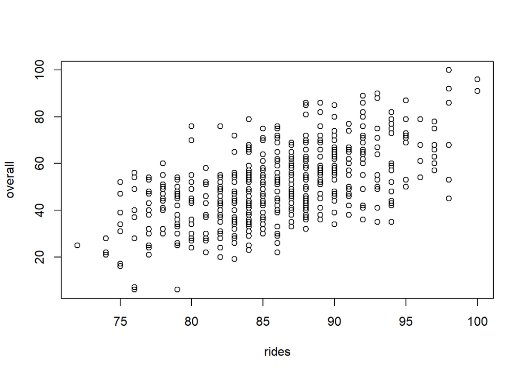

```r
attach(df)
plot(overall~rides)
```

- 전반적인 만족도(Overall)와 놀이기구에 대한 만족도(Rides)간의 관계 - 대략적으로, 양의 상관관계를 띄는 것을 볼 수 있다.

## 공분산 및 상관계수

```r
cov(overall, rides)
```

```
## [1] 50.82939
```

- 50.83은 양수이므로 두 변수간의 상관 관계는 “상승하는 경향”을 보인다.

```r
cor(overall, rides, use='complete.obs', method='pearson')
```

```
## [1] 0.5859863
```

```r
# use='complete.obs' => 결측값을 모두 제거된 상태에서 계산
```

- 0.59는 0.3~0.7 사이이므로 “뚜렷한 양적 선형관계”이다.

## 상관계수의 검정

```r
cor.test(overall, rides)
```

```
##
##  Pearson's product-moment correlation
##
## data:  overall and rides
## t = 16.138, df = 498, p-value < 2.2e-16
## alternative hypothesis: true correlation is not equal to 0
## 95 percent confidence interval:
##  0.5252879 0.6407515
## sample estimates:
##       cor
## 0.5859863
```

- 귀무가설: 전반적인 만족도와 놀이기구에 대한 만족도는 상관이 없다.
- 대립가설: 전반적인 만족도와 놀이기구에 대한 만족도는 상관이 있다.
- p-value는 0.05보다 작기 때문에 귀무가설을 기각할 수 있다. 따라서 전반적인 만족도와 놀이기구에 대한 만족도는 상관이 있다는 것을 확인할 수 있다.

## 다른 변수들간의 상관관계

```r
library(corrplot)
cor(df[,4:8])
```

```
##             rides     games      wait     clean   overall
## rides   1.0000000 0.4551851 0.3141995 0.7895651 0.5859863
## games   0.4551851 1.0000000 0.2991050 0.5169799 0.4374679
## wait    0.3141995 0.2991050 1.0000000 0.3678847 0.5726217
## clean   0.7895651 0.5169799 0.3678847 1.0000000 0.6393982
## overall 0.5859863 0.4374679 0.5726217 0.6393982 1.0000000
```

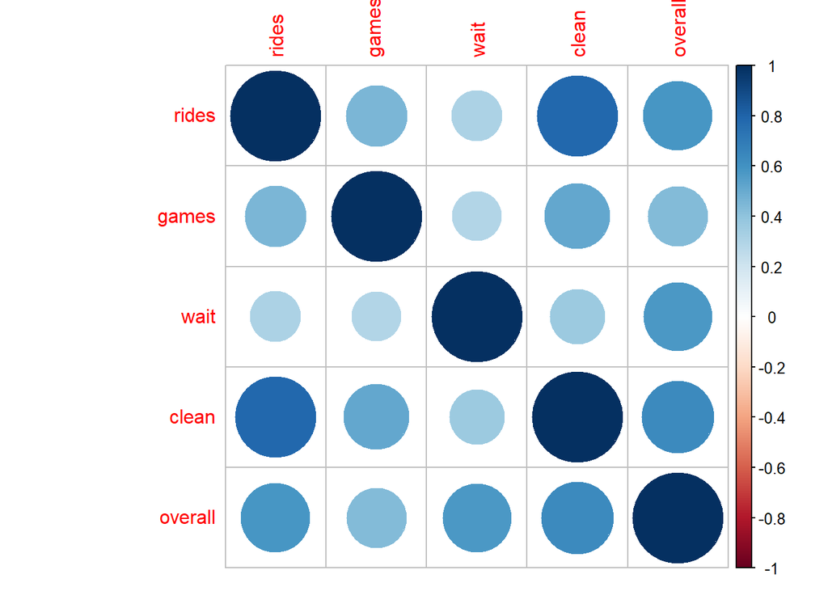

```r
X <- cor(df[,4:8])
corrplot(X)
```

- corrplot() 함수를 통해서 각각의 값들간의 상관관계를 시각적으로 표현할 수 있다.